# Hourly and Daily Demand Pattern Analysis for NYC Taxi Trips

AzizovA

15 noy 2026

## Giriş

Bu analizdə NYC taksi səfərləri datasında (Kaggle: *NYC Taxi Trip Duration*, `train.csv`) tələbatın saat, həftənin günü və ay üzrə necə dəyişdiyi öyrənilir. Analiz **R dilində** aparılıb

## Setup

```r
library(tidyverse)
library(lubridate)
library(scales)


dir.create("figures", showWarnings = FALSE)

df=read.csv("NYC.csv")
```

## Datanın ilkin yoxlanışı

```r
dim(df)                 # sətir və sütun sayı
```

```
## [1] 1458644      11
```

```r
glimpse(df)             # sütun tipləri
```

```
## Rows: 1,458,644
## Columns: 11
## $ id                 <chr> "id2875421", "id2377394", "id3858529", "id3504673",…
## $ vendor_id          <int> 2, 1, 2, 2, 2, 2, 1, 2, 1, 2, 2, 2, 2, 2, 2, 1, 2, …
## $ pickup_datetime    <chr> "2016-03-14 17:24:55", "2016-06-12 00:43:35", "2016…
## $ dropoff_datetime   <chr> "2016-03-14 17:32:30", "2016-06-12 00:54:38", "2016…
## $ passenger_count    <int> 1, 1, 1, 1, 1, 6, 4, 1, 1, 1, 1, 4, 2, 1, 1, 1, 1, …
## $ pickup_longitude   <dbl> -73.98215, -73.98042, -73.97903, -74.01004, -73.973…
## $ pickup_latitude    <dbl> 40.76794, 40.73856, 40.76394, 40.71997, 40.79321, 4…
## $ dropoff_longitude  <dbl> -73.96463, -73.99948, -74.00533, -74.01227, -73.972…
## $ dropoff_latitude   <dbl> 40.76560, 40.73115, 40.71009, 40.70672, 40.78252, 4…
## $ store_and_fwd_flag <chr> "N", "N", "N", "N", "N", "N", "N", "N", "N", "N", "…
## $ trip_duration      <int> 455, 663, 2124, 429, 435, 443, 341, 1551, 255, 1225…
```

```r
colSums(is.na(df))      # hər sütunda boş (missing) dəyər sayı
```

```
##                 id          vendor_id    pickup_datetime   dropoff_datetime
##                  0                  0                  0                  0
##    passenger_count   pickup_longitude    pickup_latitude  dropoff_longitude
##                  0                  0                  0                  0
##   dropoff_latitude store_and_fwd_flag      trip_duration
##                  0                  0                  0
```

## pickup_datetime-ı datetime tipinə çevirmək

```r
df <- df %>%
  mutate(pickup_datetime = ymd_hms(pickup_datetime))

class(df$pickup_datetime)
```

```
## [1] "POSIXct" "POSIXt"
```

```r
#Müddəti dəqiqəyə çevirmək
df <- df %>%
  mutate(trip_duration_min = trip_duration / 60)

summary(df$trip_duration_min)
```

```
##      Min.   1st Qu.    Median      Mean   3rd Qu.      Max.
##     0.017     6.617    11.033    15.992    17.917 58771.367
```

**Şərh:** `pickup_datetime` mətn tipindən `POSIXct` tipinə çevrilir ki, saat və gün çıxarmaq mümkün olsun. `trip_duration` saniyə ilədir, 60-a bölünərək dəqiqəyə çevrilir. `summary` çıxışında maksimum dəyərin çox böyük olması outlier-lərin olduğunu göstərir.

## Outlier filtri (1 dəq-dən az, 120 dəq-dən çox)

```r
n_before <- nrow(df)

cat("1 dəq-dən qısa:", sum(df$trip_duration_min < 1), "\n")
```

```
## 1 dəq-dən qısa: 8595
```

```r
cat("120 dəq-dən uzun:", sum(df$trip_duration_min > 120), "\n")
```

```
## 120 dəq-dən uzun: 2253
```

```r
df_clean <- df %>%
  filter(trip_duration_min >= 1, trip_duration_min <= 120)

n_after   <- nrow(df_clean)
n_removed <- n_before - n_after
cat("Silinən sətir:", n_removed, "(", round(n_removed / n_before * 100, 2), "% )\n")
```

```
## Silinən sətir: 10848 ( 0.74 % )
```

```r
cat("Qalan sətir:", n_after, "\n")
```

```
## Qalan sətir: 1447796
```

```r
# Filtrdən əvvəl və sonra müqayisə (tapşırıq "impact" istəyir)
tibble(
  dataset = c("Əvvəl", "Sonra"),
  mean_min = c(mean(df$trip_duration_min), mean(df_clean$trip_duration_min)),
  median_min = c(median(df$trip_duration_min), median(df_clean$trip_duration_min)),
  max_min = c(max(df$trip_duration_min), max(df_clean$trip_duration_min))
)
```

```
## # A tibble: 2 × 4
##   dataset mean_min median_min max_min
##   <chr>      <dbl>      <dbl>   <dbl>
## 1 Əvvəl       16.0       11.0  58771.
## 2 Sonra       14.0       11.1    120.
```

**Şərh:** 1 dəqiqədən qısa və 120 dəqiqədən uzun səfərlər silinir. Neçə sətrin silindiyi və filtrdən əvvəl/sonra orta, median, maksimum müqayisə edilir. Ortalama və maksimumun kəskin dəyişməsi outlier-lərin təsirini göstərir, median isə az dəyişir.

## Zaman komponentləri

```r
wd_levels <- c("Monday","Tuesday","Wednesday","Thursday","Friday","Saturday","Sunday")

df_clean <- df_clean %>%
  mutate(
    hour        = hour(pickup_datetime),
    weekday_num = wday(pickup_datetime, week_start = 1),   # 1 = Monday
    weekday     = factor(weekday_num, levels = 1:7, labels = wd_levels),
    month       = month(pickup_datetime),
    day_type    = if_else(weekday_num >= 6, "Weekend", "Weekday")
  )

# Yoxlama
df_clean %>% select(pickup_datetime, hour, weekday, month, day_type) %>% head()
```

```
##       pickup_datetime hour   weekday month day_type
## 1 2016-03-14 17:24:55   17    Monday     3  Weekday
## 2 2016-06-12 00:43:35    0    Sunday     6  Weekend
## 3 2016-01-19 11:35:24   11   Tuesday     1  Weekday
## 4 2016-04-06 19:32:31   19 Wednesday     4  Weekday
## 5 2016-03-26 13:30:55   13  Saturday     3  Weekend
## 6 2016-01-30 22:01:40   22  Saturday     1  Weekend
```

```r
range(df_clean$pickup_datetime)   # data hansı aralığı əhatə edir
```

```
## [1] "2016-01-01 00:00:17 UTC" "2016-06-30 23:59:39 UTC"
```

**Şərh:** Saat, həftənin günü (Bazar ertəsi = 1), ay və iş günü/həftə sonu sütunları çıxarılır. `range` datanın hansı tarixləri əhatə etdiyini göstərir

## Saat üzrə səfər sayı + line chart

```r
hourly <- df_clean %>% count(hour, name = "trips")

peak     <- hourly %>% slice_max(trips, n = 3)
off_peak <- hourly %>% slice_min(trips, n = 3)
peak; off_peak
```

```
##   hour trips
## 1   18 90022
## 2   19 89753
## 3   21 83607
```

```
##   hour trips
## 1    5 14767
## 2    4 15524
## 3    3 20637
```

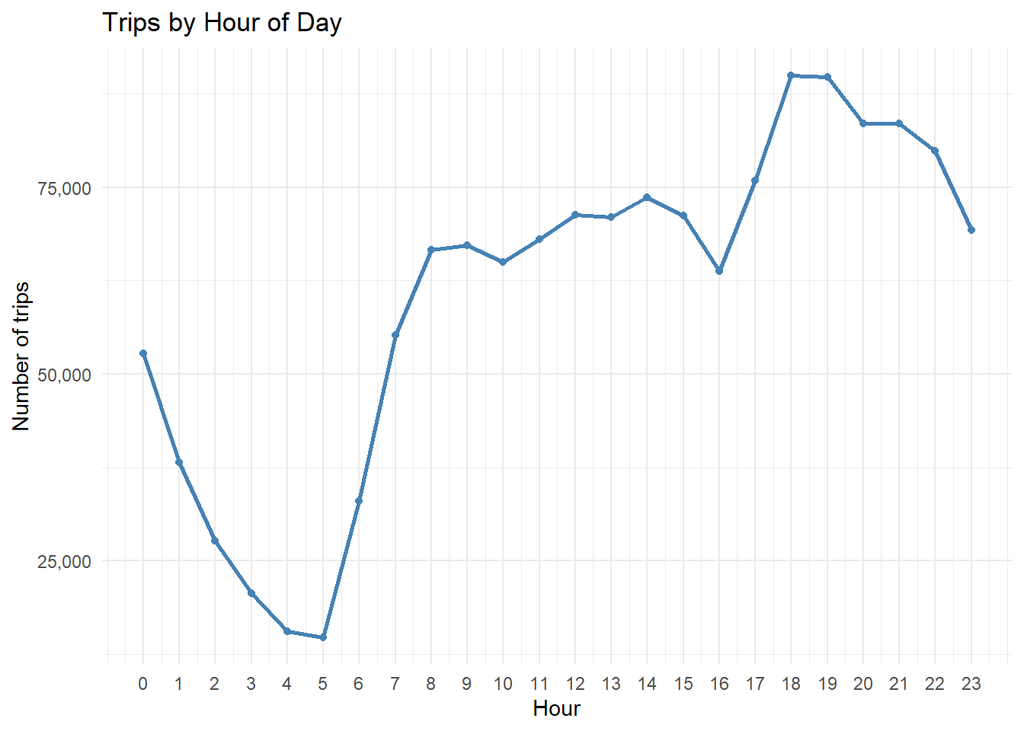

```r
p1 <- ggplot(hourly, aes(hour, trips)) +
  geom_line(color = "steelblue", linewidth = 1) +
  geom_point(color = "steelblue") +
  scale_x_continuous(breaks = 0:23) +
  scale_y_continuous(labels = comma) +
  labs(title = "Trips by Hour of Day", x = "Hour", y = "Number of trips") +
  theme_minimal()

p1
```

```r
ggsave("figures/01_trips_by_hour.png", p1, width = 9, height = 5, dpi = 150)
```

**Şərh:** Hər saat üçün səfər sayı hesablanır, ən yüksək (peak) və ən aşağı (off-peak) 3 saat tapılır və line chart çəkilir.

## Həftənin günü üzrə səfər sayı + bar chart

```r
weekly <- df_clean %>% count(weekday, name = "trips")
weekly
```

```
##     weekday  trips
## 1    Monday 186051
## 2   Tuesday 201318
## 3 Wednesday 208751
## 4  Thursday 216947
## 5    Friday 221870
## 6  Saturday 219190
## 7    Sunday 193669
```

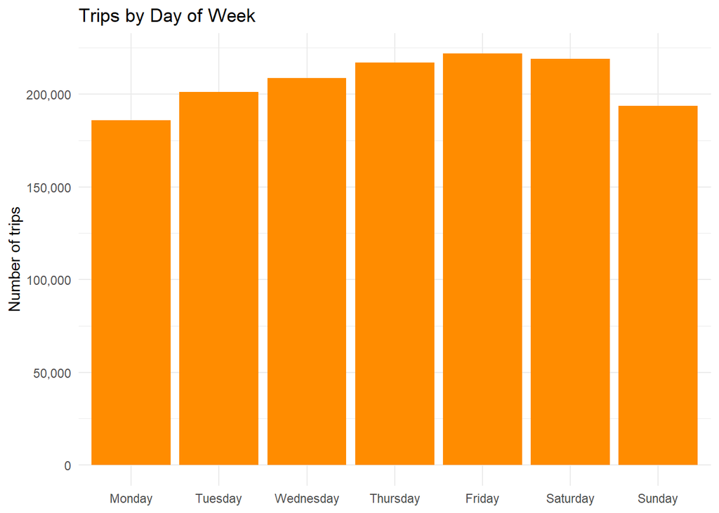

```r
p2 <- ggplot(weekly, aes(weekday, trips)) +
  geom_col(fill = "darkorange") +
  scale_y_continuous(labels = comma) +
  labs(title = "Trips by Day of Week", x = NULL, y = "Number of trips") +
  theme_minimal()

p2
```

```r
ggsave("figures/02_trips_by_weekday.png", p2, width = 9, height = 5, dpi = 150)

#Weekday vs weekend müqayisəsi: 5 iş günü ilə 2 həftə sonunu birbaşa toplayıb müqayisə etmək düzgün deyil. Ona görə gündəlik orta götürürəm:
daily_by_type <- df_clean %>%
  mutate(date = as_date(pickup_datetime)) %>%
  count(date, day_type, name = "trips") %>%
  group_by(day_type) %>%
  summarise(avg_trips_per_day = mean(trips), .groups = "drop")

daily_by_type
```

```
## # A tibble: 2 × 2
##   day_type avg_trips_per_day
##   <chr>                <dbl>
## 1 Weekday              7961.
## 2 Weekend              7940.
```

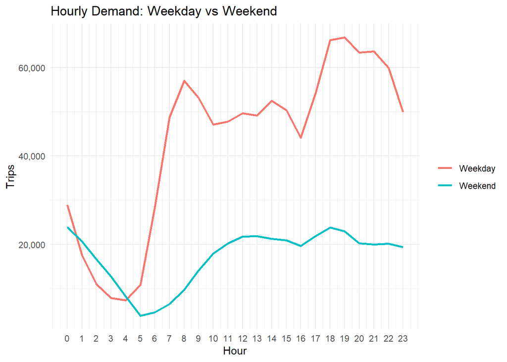

```r
# Həftə içi / həftə sonu saatlıq profil fərqi (insight üçün faydalıdır)
hourly_by_type <- df_clean %>%
  count(hour, day_type, name = "trips")

p_type <- ggplot(hourly_by_type, aes(hour, trips, color = day_type)) +
  geom_line(linewidth = 1) +
  scale_x_continuous(breaks = 0:23) +
  scale_y_continuous(labels = comma) +
  labs(title = "Hourly Demand: Weekday vs Weekend", x = "Hour", y = "Trips", color = NULL) +
  theme_minimal()

p_type
```

```r
ggsave("figures/08_hourly_weekday_vs_weekend.png", p_type, width = 9, height = 5, dpi = 150)
```

**Şərh:** Həftənin günləri üzrə səfər sayı bar chart ilə göstərilir. İş günü ilə həftə sonu **gündəlik orta** ilə müqayisə olunur (5 gün ilə 2 günü birbaşa toplamaq düzgün olmazdı). Sonuncu qrafik iki gün tipinin saatlıq tələbat profilini göstərir, yəni tələbatın zirvəsinin həftə sonu fərqli saatda olub-olmadığını görmək olur.

## Saat üzrə orta səfər müddəti

```r
avg_dur_hour <- df_clean %>%
  group_by(hour) %>%
  summarise(avg_duration_min = mean(trip_duration_min),
            median_duration_min = median(trip_duration_min),
            .groups = "drop")

avg_dur_hour
```

```
## # A tibble: 24 × 3
##     hour avg_duration_min median_duration_min
##    <int>            <dbl>               <dbl>
##  1     0             13.1               10.8
##  2     1             12.4               10.3
##  3     2             11.8                9.92
##  4     3             11.8                9.93
##  5     4             12.4               10.3
##  6     5             12.0                8.77
##  7     6             11.3                7.93
##  8     7             12.7                9.62
##  9     8             14.0               11.0
## 10     9             14.1               11.4
## # ℹ 14 more rows
```

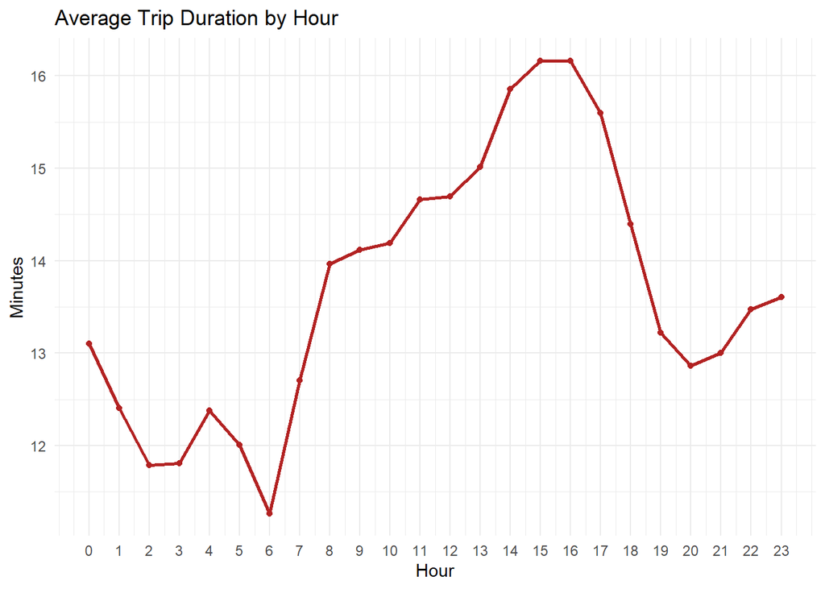

```r
p_dur_hour <- ggplot(avg_dur_hour, aes(hour, avg_duration_min)) +
  geom_line(color = "firebrick", linewidth = 1) +
  geom_point(color = "firebrick") +
  scale_x_continuous(breaks = 0:23) +
  labs(title = "Average Trip Duration by Hour", x = "Hour", y = "Minutes") +
  theme_minimal()

p_dur_hour
```

```r
ggsave("figures/05_avg_duration_by_hour.png", p_dur_hour, width = 9, height = 5, dpi = 150)
```

**Şərh:** Hər saat üçün orta və median səfər müddəti hesablanır. Müddətin uzandığı saatlar adətən tıxac saatlarıdır, bu isə fleet planlaşdırması üçün vacib insight-dır (eyni səfər daha çox vaxt aparır, yəni maşın daha az səfər edə bilir).

## Səfər müddəti histoqramı

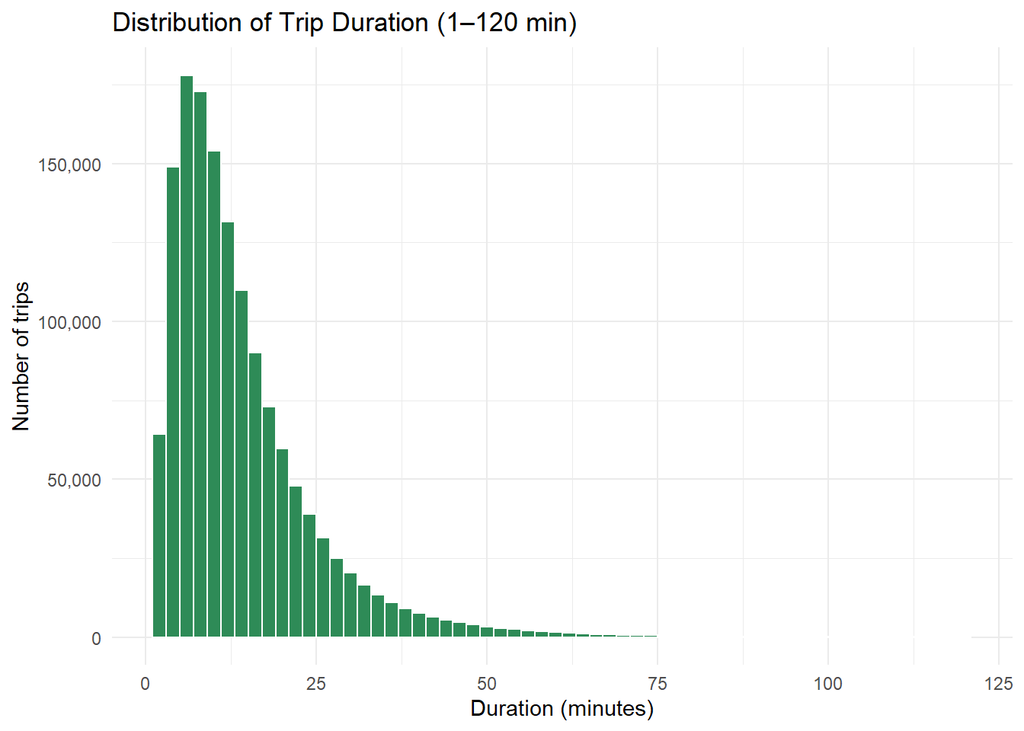

```r
p3 <- ggplot(df_clean, aes(trip_duration_min)) +
  geom_histogram(binwidth = 2, fill = "seagreen", color = "white") +
  scale_y_continuous(labels = comma) +
  labs(title = "Distribution of Trip Duration (1–120 min)",
       x = "Duration (minutes)", y = "Number of trips") +
  theme_minimal()

p3
```

```r
ggsave("figures/03_duration_histogram.png", p3, width = 9, height = 5, dpi = 150)

# note üçün ümumi statistika
df_clean %>%
  summarise(mean = mean(trip_duration_min),
            median = median(trip_duration_min),
            sd = sd(trip_duration_min),
            q25 = quantile(trip_duration_min, .25),
            q75 = quantile(trip_duration_min, .75))
```

```
##       mean   median      sd      q25      q75
## 1 14.01459 11.08333 10.8877 6.683333 17.93333
```

**Şərh:** Filtrdən sonra səfər müddətlərinin paylanması göstərilir (2 dəqiqəlik aralıqlarla). Paylanma adətən sağa uzanan olur: çox sayda qısa səfər, az sayda uzun səfər. Bu səbəbdən ortalama medianın üstündə çıxır.

## Aylıq trend (bar chart)

```r
monthly <- df_clean %>% count(month, name = "trips")
monthly
```

```
##   month  trips
## 1     1 228064
## 2     2 236609
## 3     3 254306
## 4     4 249713
## 5     5 246579
## 6     6 232525
```

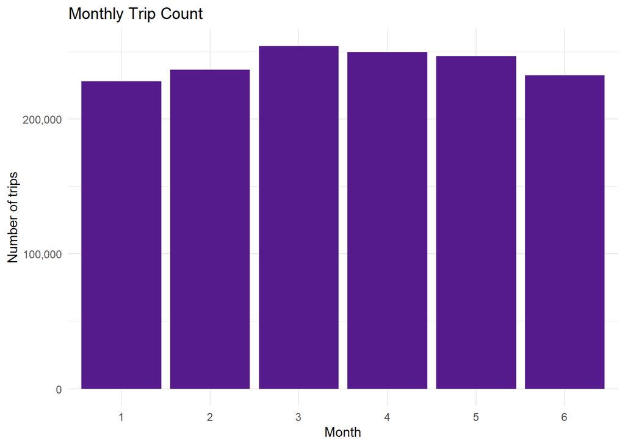

```r
p4 <- ggplot(monthly, aes(factor(month), trips)) +
  geom_col(fill = "purple4") +
  scale_y_continuous(labels = comma) +
  labs(title = "Monthly Trip Count", x = "Month", y = "Number of trips") +
  theme_minimal()

p4
```

```r
ggsave("figures/04_monthly_trips.png", p4, width = 9, height = 5, dpi = 150)

# Aylıq orta müddət (note-dakı "aprel" iddiasını yoxlamaq üçün)
df_clean %>%
  group_by(month) %>%
  summarise(avg_duration_min = mean(trip_duration_min), .groups = "drop")
```

```
## # A tibble: 6 × 2
##   month avg_duration_min
##   <dbl>            <dbl>
## 1     1             13.2
## 2     2             13.2
## 3     3             13.7
## 4     4             14.2
## 5     5             14.8
## 6     6             14.9
```

**Şərh:** Aylıq səfər sayı bar chart ilə göstərilir. Data cəmi 6 aylıq olduğu üçün bu, tam mövsümilik yox, qısa dövr tendensiyasıdır. Aylıq orta müddət cədvəli hansı ayın ən uzun səfərlərə malik olduğunu göstərir.

## Heatmap (saat × gün)

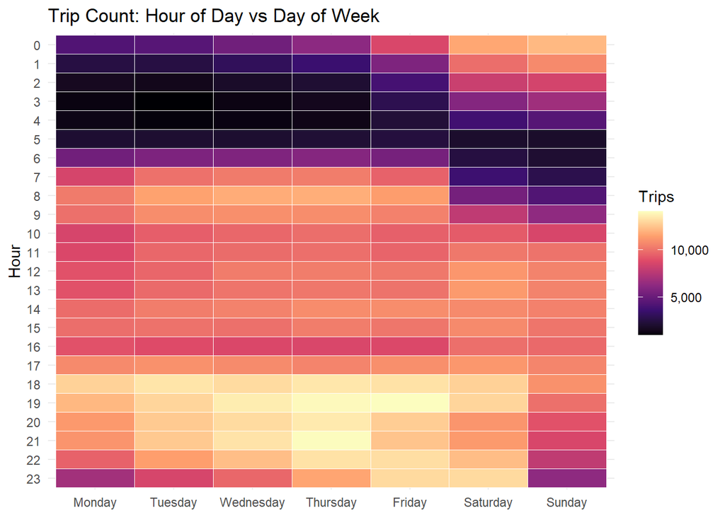

```r
heat <- df_clean %>% count(hour, weekday, name = "trips")

p_heat <- ggplot(heat, aes(weekday, factor(hour), fill = trips)) +
  geom_tile(color = "white") +
  scale_fill_viridis_c(option = "magma", labels = comma) +
  scale_y_discrete(limits = rev(as.character(0:23))) +   # 0 yuxarıda
  labs(title = "Trip Count: Hour of Day vs Day of Week",
       x = NULL, y = "Hour", fill = "Trips") +
  theme_minimal()

p_heat
```

```r
ggsave("figures/06_heatmap_hour_weekday.png", p_heat, width = 9, height = 7, dpi = 150)
```

**Şərh:** Bonus 1. Hər xana müəyyən saat və günün səfər sayını göstərir, rəng nə qədər açıqdırsa tələbat o qədər yüksəkdir. Bir qrafikdə həm saat, həm gün üzrə tələbatı görmək olur (məsələn, iş günlərinin axşam zirvəsi, həftə sonu gecə tələbatı).

## Vendor 1 vs Vendor 2

```r
vendor_cmp <- df_clean %>%
  group_by(vendor_id) %>%
  summarise(trips = n(),
            share_pct = n() / nrow(df_clean) * 100,
            avg_duration_min = mean(trip_duration_min),
            median_duration_min = median(trip_duration_min),
            .groups = "drop")
vendor_cmp
```

```
## # A tibble: 2 × 5
##   vendor_id  trips share_pct avg_duration_min median_duration_min
##       <int>  <int>     <dbl>            <dbl>               <dbl>
## 1         1 673164      46.5             13.9                11.0
## 2         2 774632      53.5             14.1                11.1
```

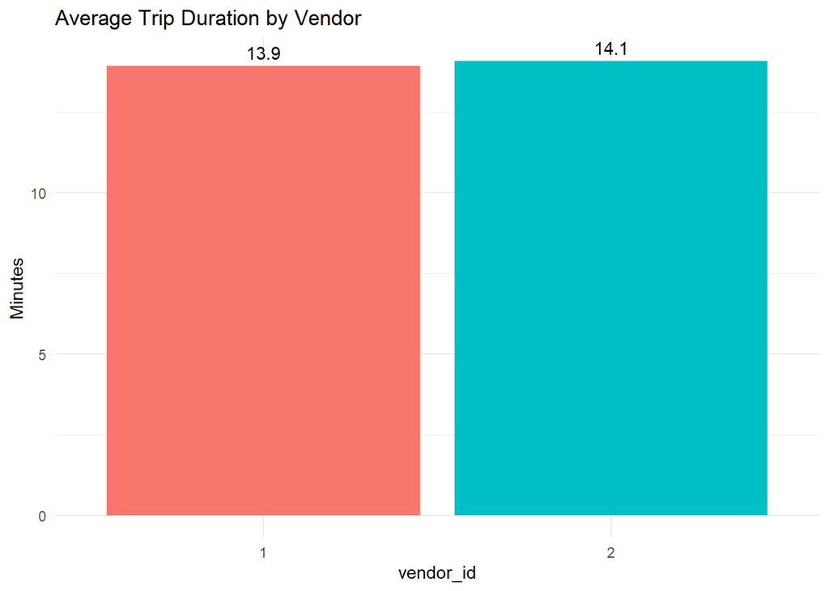

```r
p_vendor <- ggplot(vendor_cmp, aes(factor(vendor_id), avg_duration_min, fill = factor(vendor_id))) +
  geom_col(show.legend = FALSE) +
  geom_text(aes(label = round(avg_duration_min, 1)), vjust = -0.5) +
  labs(title = "Average Trip Duration by Vendor", x = "vendor_id", y = "Minutes") +
  theme_minimal()

p_vendor
```

```r
ggsave("figures/07_vendor_duration.png", p_vendor, width = 6, height = 5, dpi = 150)

# fərq statistik əhəmiyyətlidirmi?
t.test(trip_duration_min ~ vendor_id, data = df_clean)
```

```
##
##  Welch Two Sample t-test
##
## data:  trip_duration_min by vendor_id
## t = -8.3185, df = 1427442, p-value < 2.2e-16
## alternative hypothesis: true difference in means between group 1 and group 2 is not equal to 0
## 95 percent confidence interval:
##  -0.1861908 -0.1151829
## sample estimates:
## mean in group 1 mean in group 2
##        13.93397        14.08466
```

**Şərh:** Bonus 2. İki vendor üçün səfər sayı, payı və orta/median müddət müqayisə olunur. `t.test` fərqin təsadüfi olub-olmadığını yoxlayır. 1,4 milyon sətirdə çox kiçik fərq də “statistik əhəmiyyətli” çıxa bilər, ona görə p-value ilə yanaşı fərqin praktik ölçüsünə (neçə dəqiqə) də baxmaq lazımdır. `vendor_id` sürücü deyil, provayder (şirkət) kodudur.